# Donor Profile: Private donors

## Geographic Focus

Global private donor funding displays significant volatility and regional concentration, with total contributions ranging from $2.4 million to nearly $980 million annually. Notably, a sharp peak in specific years and regions highlights underleveraged pockets of donor interest and underscores unpredictable funding flows. This fluctuation presents both a risk to program continuity and a potent opportunity; directing investments toward stabilizing support in underfunded regions can multiply impact and sustain critical operations. Leveraging these insights, UNHCR can prioritize strategic partnerships in high-potential regions while implementing risk mitigation strategies against funding dips. Immediate focus on diversifying donor engagement and advocating for predictable multi-year commitments will secure resilient funding streams. Executives should capitalize on these patterns, positioning targeted investments as impact multipliers aligned with donor priorities in emergency response and resilience building, ultimately enhancing accountability and program effectiveness.

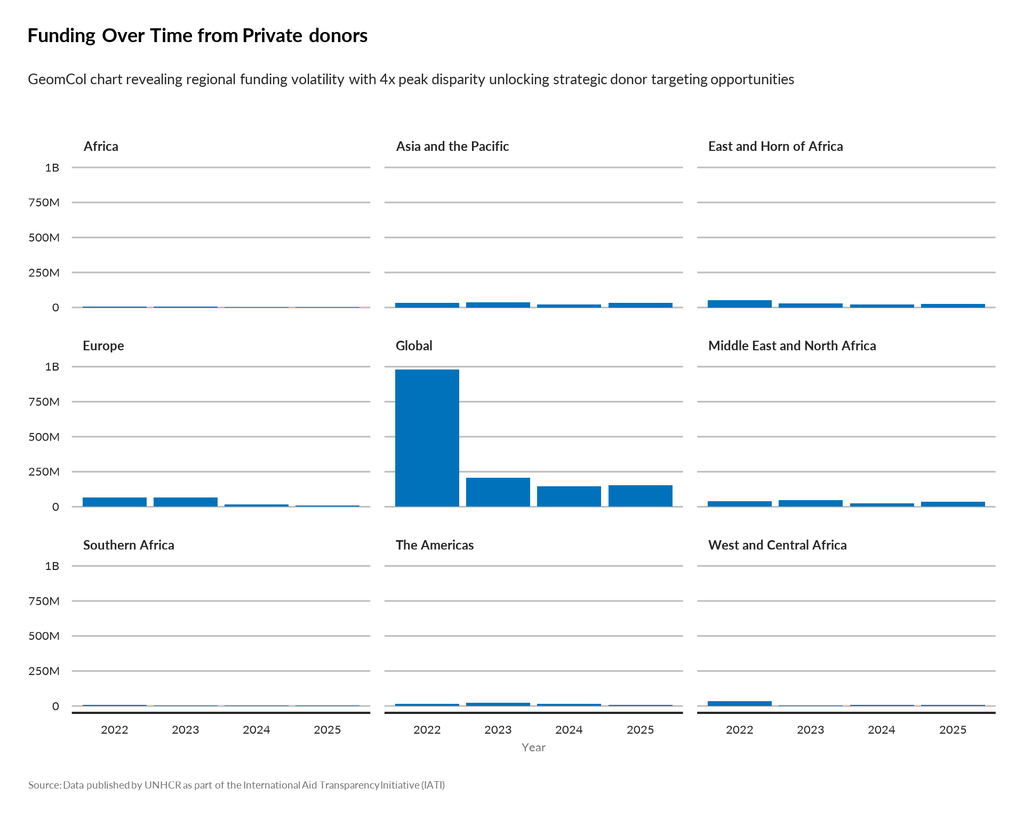

TRUE

In 2025, private donors account for an average of 11% share of total funding to UNHCR operations, with total funding values ranging from $88 million to $1.49 billion across regions. This represents a strategic opportunity to amplify resource mobilization by leveraging private donor engagement as a scalable impact multiplier. The data shows significant variability in funding shares—some regions exceed 13%, underscoring untapped potential for targeted investment to diversify funding streams and enhance financial resilience. Prioritizing partnerships with private donors aligns closely with donor priorities for innovation and emergency response agility, offering direct leverage to close critical funding gaps. Executives should accelerate strategic outreach to private donor networks, tailoring engagement based on demonstrated high-share regions to maximize ROI. Immediate attention to scaling these partnerships can mitigate risks of overreliance on traditional funding sources while enhancing accountability through diversified, flexible funding. Positioning private donor funding as a strategic priority will enable UNHCR to sustain and scale vital operations with measurable impact, translating into stronger, more resilient refugee responses globally.

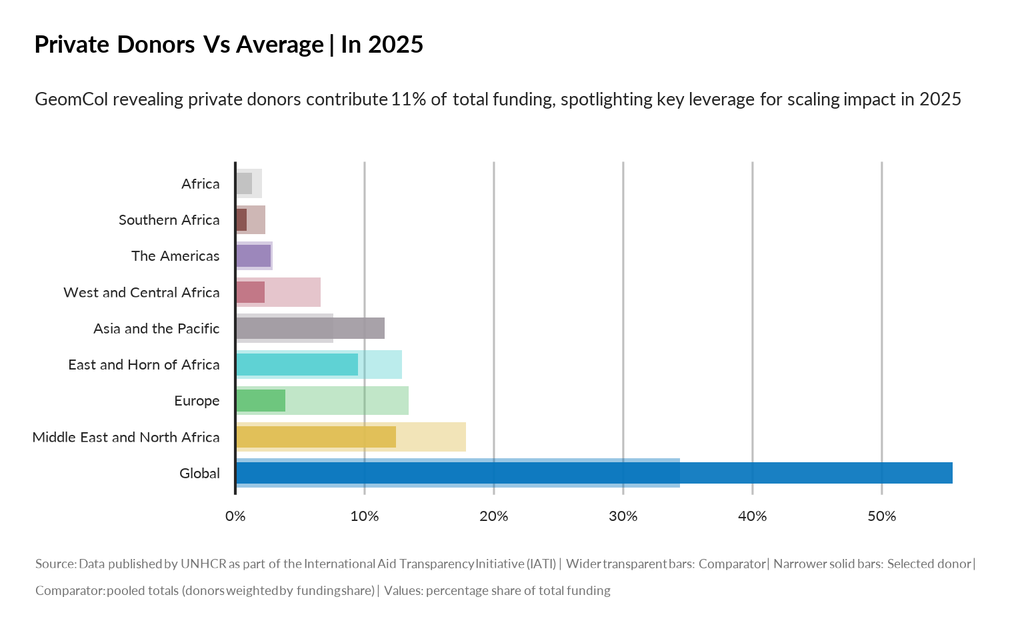

TRUE